# Introduction to Shapefiles

# Introduction

One of my more recent areas of growth as a data scientist has been learning to work with spatial data. If you have worked with yield monitor data, *ArcGIS*, or used an application map to vary the application rate of your fertilizer, you have worked with spatial data. We will learn how to plot spatial data in detail in Unit 12, but here is a brief introduction to importing and inspecting spatial data.

# R Packages

To look at spatial data, we will use the R package `sf` (short for *spatial features*). Remember, when we use a new package in R for the first time, we must install and launch it with the following commands. The `sf` package takes a while to install, so it is already installed in *RStudio Cloud*. As a reminder, however, the installation code is included below. In this case it has a hashtag (#) in front of it. The hashtag converts code to a **comment**; any code that follows a hashtag on the same line will not be run. This is a useful way to block code we don’t want to run, or add an explanation about code we are running

Go ahead and restart R and clear the output, as you learned in the *summary statistics* exercise, then install and load the `sf` package with the code below:

```r
# install.packages('sf')
library(sf) # this loads the sf package
```

# Reading Shapefiles

To read in a shape file, we use the `st_read()` function. We read in a shape file the same way we read in a .csv file in the previous exercise. We follow `st_read()` with the path to the shape file, which has a .shp suffix.

If you view a shape file in the file directory, it is usually accompanied by identically named files with different extensions (the three letters after the last period). For example, if you navigate to the directory *Cloud>project>exercises>data>Agriculture_Census-shp* in the window in the lower right, you will see the *Agriculture_Census.shp file, but also Agriculture_Census.prj* and three other files. These additional files tell R how to draw the shapefile as a map. Reading in the shape file (*Agriculture_Census.shp*) will cause these other files to be read in automatically.

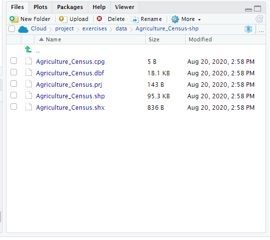

We will read in a shape file from Indiana that includes county summaries for a couple of dozen agricultural statistics.

```r
indiana = st_read("data/Agriculture_Census-shp/Agriculture_Census.shp")
```

# Examining Spatial Feature Data Frames

Let’s inspect the first six rows of the spatial feature data frame using the `head()` command, where the name of the data frame is given between the parentheses.

```r
head(indiana)
```

```
Simple feature collection with 6 features and 31 fields
Geometry type: POLYGON
Dimension:     XY
Bounding box:  xmin: -87.52704 ymin: 41.16195 xmax: -84.80631 ymax: 41.76233
CRS:           4326
  OBJECTID AGCENSP020              COUNTY N_FARM TOTCROP_AC HAVCROP_AC DOL_FARM NURS_DOL LVSTOK_DOL SALE_2500 SALE_5000 EXPEN_1000 NURSY_1000
1        1       2515      Elkhart County   1335     160160     143324    92912    34688      89350       251       100      96862        514
2        2       2516 Saint Joseph County    666     139661     131004    82849    40051      15127       144        71      40479        583
3        3       2517     La Porte County    749     226816     212940   127922    68041      27773       136        60      71666        742
4        4       2518      Steuben County    581      99218      71944    44133    16776       8865       236        44      20288          0
5        5       2519     Lagrange County   1392     156233     127875    74194    37364      65915       223       105      83668          0
6        6       2539         Lake County    442     138929     132551   108206    42747       5080       101        30      34712         66
  N_CHICKENS N_CATTLE N_PIGS CORN_AC WHEAT_AC COTTON_AC SOYBEAN_AC VEGTABL_AC ORCHARD_AC PECAN_AC IRRGTD_AC N_MACHINE FEMALE_OP MINORTY_OP
1    3005354    42719  73951   64955     3861         0      42251       1338          0        0     23524       495        32          0
2        852     6440  27430   69251     4073         0      45696        480          0        0     12941       444        44          3
3      -9999    24980  27110  113242     4186         0      76809       1125          0        0     27090       631        44          0
4      -9999     9257   6859   32152     4483         0      25120        304          0        0      1225     -9999        42          0
5    1870836    39275  69338   61262     3993         0      32666       1182          0        0     23478       315        26          0
6          0     3204   9435   68344     3101         0      55698       1256          0        0      6211       327        42          3
  FAM_FARM igs_DBO_Ag SHAPE_Leng SHAPE_Area                       geometry
1     1164          0   139058.4 1210349270 POLYGON ((-86.06246 41.7619...
2      584          0   155098.8 1196846667 POLYGON ((-86.22555 41.7614...
3      626          0   175216.0 1563031845 POLYGON ((-86.82619 41.7608...
4      505          0   116305.4  835438144 POLYGON ((-85.19779 41.7605...
5     1232          0   128976.5 1000327995 POLYGON ((-85.29134 41.7606...
6      356          0   167477.6 1300778609 POLYGON ((-87.52401 41.7135...
```

Spatial feature data frames are very similar to the data frames that were introduced to in the last exercise. There are a few differences, however. First, every spatial feature data frame consists of rows of observations that are linked, in the geometry column, with a georeference. That georeference may be a simple point on the map, or it may be a polygon that defines an area, such as a field, a county, or a state.

Spatial feature data frames also include some metadata about the geometry of the file, including geometry type (POLYGON in this case, since we are working with county outlines) and – this is critical – *CRS*. CRS stands for **coordinate reference system**, the “projection” we use to draw a map, and the georeferences used to define a place or area.

Maps are flat representations of a round object, and there are different ways to draw these maps. We need not go into a deep review of those projects at this point; suffice it to know that each projection represents tradeoffs in how accurately it portrays areas in the center and periphery of the map and how much it represents the curvature. For most of my work, I use the CRS of 4326. You know this system more commonly as the latitude/longitude system.

The bounding box defines where the map is centered. Latitude/longitude maps are more accurate in portraying areas near the center of the map than the periphery, so it is important the map be centered on the area of interest.

Don’t worry about committing the above information to memory for now, we will discuss projection is much greater detail in Unit 12.